# Perception, Cognition, and Emotion

Session 1

Luis F. Gómez L.

luis.gomezl@unimilitar.edu.co

Distance Learning Faculty

8 September, 2026

# Please Read Me

- Check the message **Welcome greeting** published in the News Bulletin Board.
- Dear student please edit your profile uploading a photo where your face is clearly visible.
- The purpose of the virtual meetings is to answer questions and not to make a summary of the study material.
- This presentation is based on (Lewicki et al., 2024, Chapter 6)
- **Purpose**
  - Examine how perceptual biases, cognitive processing, and emotional dynamics directly influence negotiation behavior and outcomes.

# Perception

- **Perception** is defined as the process by which individuals acquire information from their environment through the senses.
  - Individuals actively construct impressions based on this information, guiding their subsequent behavior
- The distortions of the perception may occur when the impressions that are generated don’t reflect the real aspects of a situation.
  - This type of distortions are known as **cognitive biases**
- Example of a distortion in perception

[figure not shown]

Figure 1: Checker Shadow illusion (Adelson, 1995)

- Example of a distortion in perception

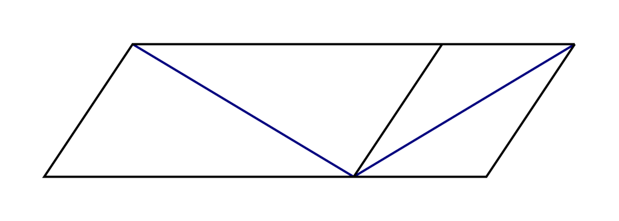

Figure 2: Sander’s parallelogram (Luckiesh, 2017)

- Example of a distortion in perception

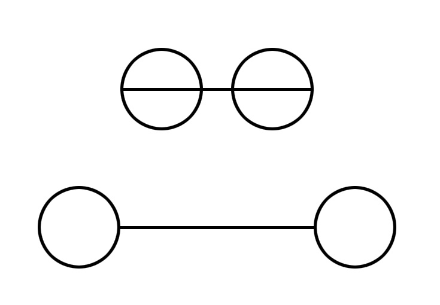

Figure 3: Müller-Lyer Illusion (Zeman et al., 2013)

# Framing

- **Framing** is a concept initially coined by (Bateson, 2000) and developed by (Goffman, 1986).
  - It is defined as the interpretation schemes that individuals use to understand reality and act based on the interpretation they perform.
- In general terms, this means that individuals have built mental filters throughout their lives that allow them to understand the world. In turn, these mental filters influence the decisions they make.
- Example of how **framing** can change decisions depending on how information is presented (Tversky & Kahneman, 1981, p 453):
  - **Problem 1** [N = 152][^1]: Imagine that the U.S. is preparing for the outbreak of an unusual Asian disease, which is expected to kill 600 people. Two alternative programs to combat the disease have been proposed. Assume that the exact scientific estimate of the consequences of the programs are as follows:
    - If Program A is adopted, 200 people will be saved. **[72 percent]**[^2]
    - If Program B is adopted, there is 1/3 probability that 600 people will be saved, and 2/3 probability that no people will be saved. **[28 percent]**[^3]
  - Which of the two programs would you favor?
- Example of how **framing** can change decisions depending on how information is presented (Tversky & Kahneman, 1981, p 453):
  - **Problem 2** [N = 155][^4]: The same statement as **Problem 1**
    - If Program C is adopted, 400 people will die. **[22 percent]**[^5]
    - If Program D is adopted there is 1/3 probability that nobody will die, and 2/3 probability that 600 people will die. **[78 percent]**[^6]
  - Which of the two programs would you favor?
- **Problem 1** and **Problem 2** are equivalent but they are frame in a different way. This is why the majority choice in **Problem 1** is Program A and for the **Problem 2** is Program D.
- In the field of negotiation you can also influence the perception of the counterpart through framing. An introduction to this topic can be found in (Shonk, 2020):
  - Offer Manageable Choices (Iyengar & Lepper, 2000)
  - Make Several Offers (Leonardelli et al., 2019)
  - Be Willing to Be Rejected (Simonson & Tversky, 1992)

# Cognitive Biases in Negotiation

- A **cognitive bias** is defined as a systematic error that affects the decisions and judgments.

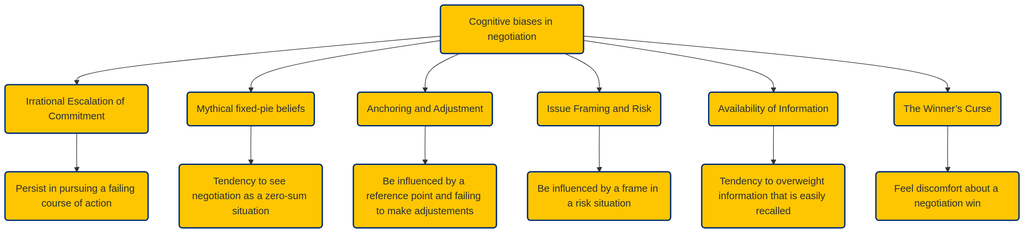

Figure 4: Cognitive biases in the context of a negotiation[^7]

- A **cognitive bias** is defined as a systematic error that affects the decisions and judgments.

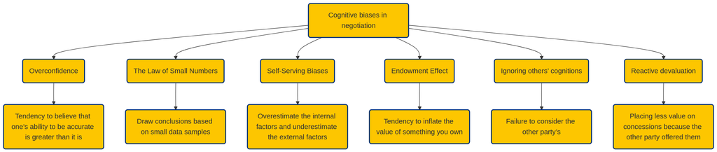

Figure 5: Cognitive biases in the context of a negotiation[^8]

# An alternative approach: Mood and Emotion

- The study of **cognitive biases** in negotiation is focused on how negotiators make judgment errors or how can negotiators can mitigate or eliminate this errors to improve the decision making process.
- Another approach is to use emotions as a strategic tool in negotiations[^9] by adjusting the negotiation stance based on the other party’s emotional state.

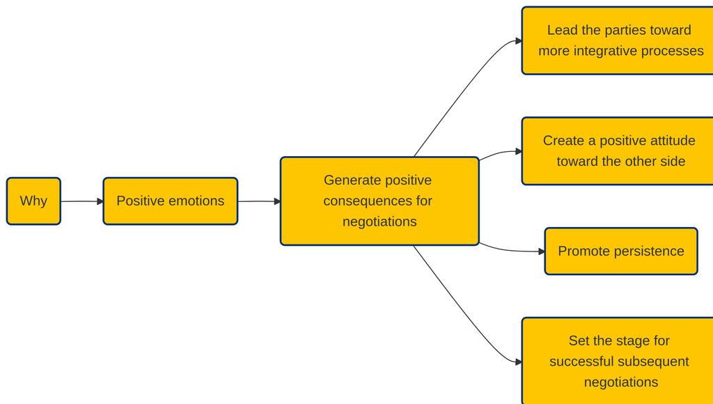

Figure 6: Positive emotions and consequences for negotiations (Lewicki et al., 2024, p. 202)

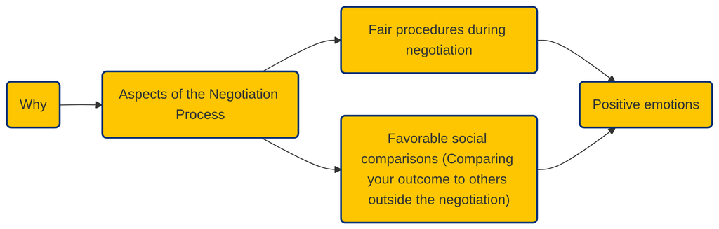

Figure 7: Aspects of the negotiation process and positive emotions (Lewicki et al., 2024, p. 203)

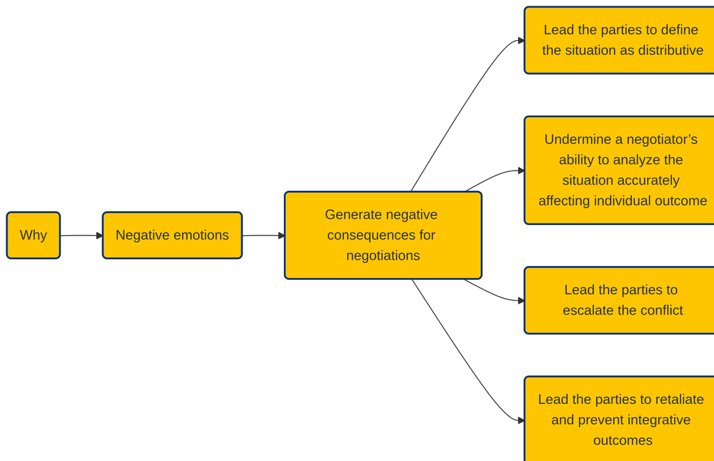

Figure 8: Negative emotions and consequences for negotiations (Lewicki et al., 2024, pp. 203–204)

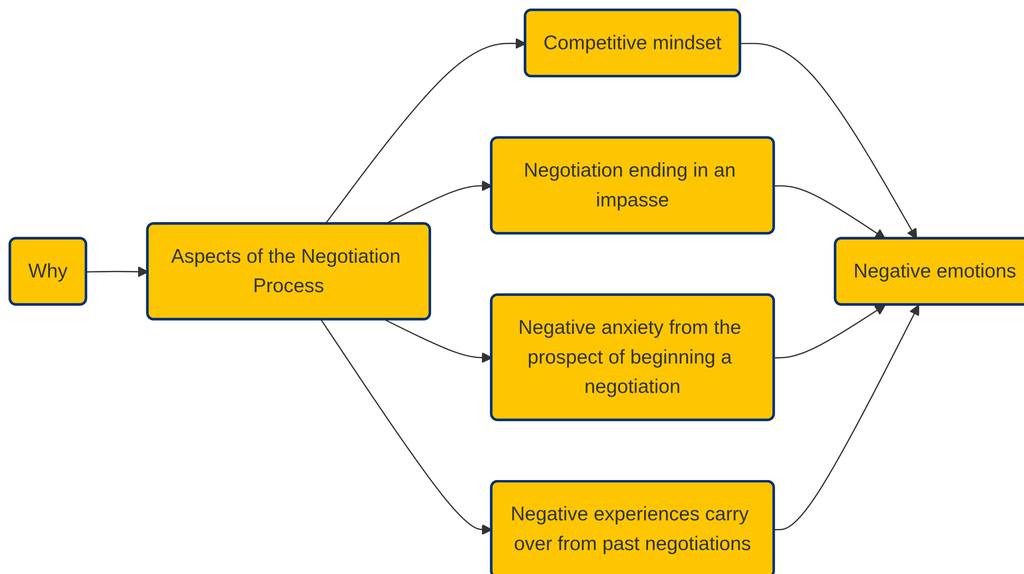

Figure 9: Aspects of the negotiation process and negative emotions (Lewicki et al., 2024, p. 205)

# Acknowledgments

- To my family that supports me
- To the taxpayers of Colombia and the [**UMNG students**](https://www.umng.edu.co/estudiante) who pay my salary
- To the [**Business Science**](https://www.business-science.io/) and [**R4DS Online Learning**](https://www.rfordatasci.com/) communities where I learn [**R**](https://www.r-project.org/about.html) and [**$\pi$-thon**](https://www.python.org/about/)
- To the [**R Core Team**](https://www.r-project.org/contributors.html), the creators of [**RStudio IDE**](https://rstudio.com/products/rstudio/), [**Quarto**](https://quarto.org/) and the authors and maintainers of [**tinytex**](https://CRAN.R-project.org/package=tinytex) for allowing me to access these tools without paying for a license

# References

Adelson, E. H. (1995). *Checkershadow Illusion*. http://persci.mit.edu/gallery/checkershadow

Bateson, G. (2000). *Steps to an ecology of mind* (University of Chicago Press ed). University of Chicago Press.

Dimara, E., Franconeri, S., Plaisant, C., Bezerianos, A., & Dragicevic, P. (2020). A Task-Based Taxonomy of Cognitive Biases for Information Visualization. *IEEE Transactions on Visualization and Computer Graphics*, *26*(2), 1413–1432. https://doi.org/10.1109/TVCG.2018.2872577

Goffman, E. (1986). *Frame analysis: An essay on the organization of experience* (Northeastern University Press ed). Northeastern University Press.

Iyengar, S. S., & Lepper, M. R. (2000). When choice is demotivating: Can one desire too much of a good thing? *Journal of Personality and Social Psychology*, *79*(6), 995–1006. https://doi.org/10.1037/0022-3514.79.6.995

Leonardelli, G. J., Gu, J., McRuer, G., Medvec, V. H., & Galinsky, A. D. (2019). Multiple equivalent simultaneous offers (MESOs) reduce the negotiator dilemma: How a choice of first offers increases economic and relational outcomes. *Organizational Behavior and Human Decision Processes*, *152*, 64–83. https://doi.org/10.1016/j.obhdp.2019.01.007

Lewicki, R. J., Barry, B., & Saunders, D. M. (2024). *Negociación* (9th ed.). McGraw-Hill Education. https://www-ebooks7-24-com.ezproxy.umng.edu.co/?il=40562

Luckiesh, M. (2017). *Visual illusions: Their causes, characteristics and applications*.

Shonk, K. (2020). Framing in Negotiation. In *PON - Program on Negotiation at Harvard Law School*. https://www.pon.harvard.edu/daily/business-negotiations/framing-in-negotiation/

Simonson, I., & Tversky, A. (1992). Choice in Context: Tradeoff Contrast and Extremeness Aversion. *Journal of Marketing Research*, *29*(3), 281. https://doi.org/10.2307/3172740

Tversky, A., & Kahneman, D. (1981). The framing of decisions and the psychology of choice. *Science*, *211*(4481), 453–458. https://doi.org/10.1126/science.7455683

Zeman, A., Obst, O., Brooks, K. R., & Rich, A. N. (2013). The Müller-Lyer Illusion in a Computational Model of Biological Object Recognition. *PLoS ONE*, *8*(2), e56126. https://doi.org/10.1371/journal.pone.0056126

## Footnotes

[^1]: Number of people that participate in the experiment
[^2]: Percentage of people that choose Program A
[^3]: Percentage of people that choose Program B
[^4]: Number of people that participate in the experiment
[^5]: Percentage of people that choose Program C
[^6]: Percentage of people that choose Program D
[^7]: For a general **cognitive bias** taxonomy check out (Dimara et al., 2020)
[^8]: For a general **cognitive bias** taxonomy check out (Dimara et al., 2020)
[^9]: As a conflict negotiation professor I am quite bad at using this tool